Modelo predictivo salarios NBA Mario Arteche Miranda 2020-10-28

# Descripción de las variables

**Player**: Name and surname.

**Salary**: Players salary.

**NBA_Country** : Players country.

**NBA_DraftNumber**: Player number.

**Age**: Players age.

**Tm**: Players actual team.

**G** : Number of played matches.

**MP** : Time in minutes played.

**PER**: Player Efficiency Rating A measure of per-minute production standardized such that the league average is 15.

**TS.** : True Shooting Percentage A measure of shooting efficiency that takes into account 2-point field goals, 3-point field goals, and free throws.

**X3PAr** : 3-Point Attempt Rate Percentage of FG Attempts from 3-Point Range.

**FTr** : Free Throw Attempt Rate Number of FT Attempts Per FG Attempt.

**ORB.**: Offensive Rebound Percentage An estimate of the percentage of available offensive rebounds a player grabbed while he was on the floor.

**DRB.** : Defensive Rebound Percentage An estimate of the percentage of available defensive rebounds a player grabbed while he was on the floor.

**TRB.** : Total Rebound Percentage An estimate of the percentage of available rebounds a player grabbed while he was on the floor.

**AST.** : Assist Percentage An estimate of the percentage of teammate field goals a player assisted while he was on the floor.

**STL.** : Steal Percentage An estimate of the percentage of opponent possessions that end with a steal by the player while he was on the floor.

**BLK.** : Block Percentage An estimate of the percentage of opponent two-point field goal attempts blocked by the player while he was on the floor.

**TOV.** : Turnover Percentage An estimate of turnovers committed per 100 plays.

**USG.** : Usage Percentage An estimate of the percentage of team plays used by a player while he was on the floor.

**OWS** : Offensive Win Shares An estimate of the number of wins contributed by a player due to his offense.

**DWS** : Defensive Win Shares An estimate of the number of wins contributed by a player due to his defense.

**WS** : Win Shares An estimate of the number of wins contributed by a player.

**WS.48** : Win Shares Per 48 Minutes An estimate of the number of wins contributed by a player per 48 minutes (league average is approximately .100)

**OBPM** : Offensive Box Plus/Minus A box score estimate of the offensive points per 100 possessions a player contributed above a league-average player, translated to an average team.

**DBPM** : Defensive Box Plus/Minus A box score estimate of the defensive points per 100 possessions a player contributed above a league-average player, translated to an average team.

**BPM** : Box Plus/Minus A box score estimate of the points per 100 possessions a player contributed above a league-average player, translated to an average team.

**VORP** : Value over Replacement Player A box score estimate of the points per 100 TEAM possessions that a player contributed above a replacement-level (-2.0) player, translated to an average team and prorated to an 82-game season.

# Cargamos las librerias a emplear lectura y procesado de los datos

# lectura y procesado de los datos

- Tratamiento de los datos

## Valores unicos del data set.

```
##          Player   Salary NBA_Country NBA_DraftNumber Age  Tm  G   MP  PER   TS.
## 1       Zhou Qi   815615       China              43  22 HOU 16   87  0.6 0.303
## 2 Zaza Pachulia  3477600     Georgia              42  33 GSW 66  937 16.8 0.608
## 3 Zach Randolph 12307692         USA              19  36 SAC 59 1508 17.3 0.529
## 4   Zach LaVine  3202217         USA              13  22 CHI 24  656 14.6 0.499
## 5  Zach Collins  3057240         USA              10  20 POR 62  979  8.2 0.487
## 6  Yogi Ferrell  1312611         USA              62  24 DAL 79 2238 11.5 0.543
##   X3PAr   FTr ORB. DRB. TRB. AST. STL. BLK. TOV. USG.  OWS DWS   WS  WS.48
## 1 0.593 0.370  6.5 16.8 11.7  1.5  1.1  6.8 18.2 19.5 -0.4 0.1 -0.2 -0.121
## 2 0.004 0.337 11.0 25.0 18.5 15.4  1.9  1.3 19.3 17.2  1.7 1.4  3.1  0.160
## 3 0.193 0.140  7.0 23.8 15.0 14.9  1.4  0.6 12.5 27.6  0.3 1.1  1.4  0.046
## 4 0.346 0.301  1.4 14.4  7.7 18.6  1.8  0.5  9.7 29.5 -0.1 0.5  0.4  0.027
## 5 0.387 0.146  4.9 18.3 11.7  7.3  0.8  2.5 15.6 15.5 -0.4 1.2  0.8  0.038
## 6 0.489 0.141  1.3 11.3  6.1 13.3  1.4  0.3  9.1 17.0  1.6 1.6  3.1  0.067
##    OBPM DBPM   BPM VORP
## 1 -10.6  0.5 -10.1 -0.2
## 2  -0.6  1.3   0.8  0.7
## 3  -0.6 -1.3  -1.9  0.0
## 4  -0.7 -2.0  -2.6 -0.1
## 5  -3.7  0.9  -2.9 -0.2
## 6  -0.4 -0.5  -0.9  0.6
```

## Valores unicos de la columna Player

```
##    mData$Player
## 1       Zhou Qi
## 2 Zaza Pachulia
## 3 Zach Randolph
## 4   Zach LaVine
## 5  Zach Collins
## 6  Yogi Ferrell
```

## Numero de jugadores repetidos y eliminacion de estos

```
## [1] 2
```

```
## [1] 0
```

# Construimos nuestro modelo

### Previamente cargamos los nombres de las columnas de la base de datos para transcribirlos

```
##
## Call:
## lm(formula = Salary ~ NBA_DraftNumber + Age + G + MP + PER +
##     TS. + X3PAr + FTr + ORB. + DRB. + TRB. + AST. + STL. + BLK. +
##     TOV. + USG. + OWS + DWS + WS + WS.48 + OBPM + DBPM + BPM +
##     VORP, data = mData)
##
## Residuals:
##       Min        1Q    Median        3Q       Max
## -15354874  -3000738   -385019   2114291  21684587
##
## Coefficients:
##                 Estimate Std. Error t value Pr(>|t|)
## (Intercept)     -2257549    4909948  -0.460    0.646
## NBA_DraftNumber   -60665      12807  -4.737 2.90e-06 ***
## Age               517569      56727   9.124  < 2e-16 ***
## G                -154422      25036  -6.168 1.53e-09 ***
## MP                  5670       1087   5.217 2.76e-07 ***
## PER              -353478     281293  -1.257    0.210
## TS.             -2184162    5160879  -0.423    0.672
## X3PAr           -3441403    2364332  -1.456    0.146
## FTr              -151800     889330  -0.171    0.865
## ORB.            -1067597     906856  -1.177    0.240
## DRB.             -868491     897793  -0.967    0.334
## TRB.             2033598    1797209   1.132    0.258
## AST.              -19939      47665  -0.418    0.676
## STL.             -194112     423061  -0.459    0.647
## BLK.              110027     318948   0.345    0.730
## TOV.                4106      52808   0.078    0.938
## USG.              167442     105277   1.590    0.112
## OWS             -1323605    4518535  -0.293    0.770
## DWS             -1790690    4544903  -0.394    0.694
## WS               1877630    4523606   0.415    0.678
## WS.48            1893689   11822704   0.160    0.873
## OBPM             1935687    4772501   0.406    0.685
## DBPM             1494922    4687825   0.319    0.750
## BPM             -1353095    4705755  -0.288    0.774
## VORP              632085     635260   0.995    0.320
## ---
## Signif. codes:  0 '***' 0.001 '**' 0.01 '*' 0.05 '.' 0.1 ' ' 1
##
## Residual standard error: 5114000 on 456 degrees of freedom
##   (2 observations deleted due to missingness)
## Multiple R-squared:  0.5469, Adjusted R-squared:  0.5231
## F-statistic: 22.94 on 24 and 456 DF,  p-value: < 2.2e-16
```

## Una vez cargado y “analizado” el modelo, analizamos si cumple las 4 hipotesis de significatividad, con el modelo global

```
##
## Call:
## lm(formula = Salary ~ NBA_DraftNumber + Age + G + MP + PER +
##     TS. + X3PAr + FTr + ORB. + DRB. + TRB. + AST. + STL. + BLK. +
##     TOV. + USG. + OWS + DWS + WS + WS.48 + OBPM + DBPM + BPM +
##     VORP, data = mData)
##
## Residuals:
##       Min        1Q    Median        3Q       Max
## -15354874  -3000738   -385019   2114291  21684587
##
## Coefficients:
##                 Estimate Std. Error t value Pr(>|t|)
## (Intercept)     -2257549    4909948  -0.460    0.646
## NBA_DraftNumber   -60665      12807  -4.737 2.90e-06 ***
## Age               517569      56727   9.124  < 2e-16 ***
## G                -154422      25036  -6.168 1.53e-09 ***
## MP                  5670       1087   5.217 2.76e-07 ***
## PER              -353478     281293  -1.257    0.210
## TS.             -2184162    5160879  -0.423    0.672
## X3PAr           -3441403    2364332  -1.456    0.146
## FTr              -151800     889330  -0.171    0.865
## ORB.            -1067597     906856  -1.177    0.240
## DRB.             -868491     897793  -0.967    0.334
## TRB.             2033598    1797209   1.132    0.258
## AST.              -19939      47665  -0.418    0.676
## STL.             -194112     423061  -0.459    0.647
## BLK.              110027     318948   0.345    0.730
## TOV.                4106      52808   0.078    0.938
## USG.              167442     105277   1.590    0.112
## OWS             -1323605    4518535  -0.293    0.770
## DWS             -1790690    4544903  -0.394    0.694
## WS               1877630    4523606   0.415    0.678
## WS.48            1893689   11822704   0.160    0.873
## OBPM             1935687    4772501   0.406    0.685
## DBPM             1494922    4687825   0.319    0.750
## BPM             -1353095    4705755  -0.288    0.774
## VORP              632085     635260   0.995    0.320
## ---
## Signif. codes:  0 '***' 0.001 '**' 0.01 '*' 0.05 '.' 0.1 ' ' 1
##
## Residual standard error: 5114000 on 456 degrees of freedom
##   (2 observations deleted due to missingness)
## Multiple R-squared:  0.5469, Adjusted R-squared:  0.5231
## F-statistic: 22.94 on 24 and 456 DF,  p-value: < 2.2e-16
##
##
## ASSESSMENT OF THE LINEAR MODEL ASSUMPTIONS
## USING THE GLOBAL TEST ON 4 DEGREES-OF-FREEDOM:
## Level of Significance =  0.05
##
## Call:
##  gvlma(x = regres01)
##
##                       Value   p-value                   Decision
## Global Stat        115.6519 0.000e+00 Assumptions NOT satisfied!
## Skewness            32.2341 1.367e-08 Assumptions NOT satisfied!
## Kurtosis            50.9726 9.366e-13 Assumptions NOT satisfied!
## Link Function       31.9115 1.614e-08 Assumptions NOT satisfied!
## Heteroscedasticity   0.5336 4.651e-01    Assumptions acceptable.
```

## Tras el apartado anterior, vemos que el modelo no satisface nuestras hipotesis, por lo que deberemos seleccionar aquellas variables que deberemos eliminar o modificar

```
## Start:  AIC=14884.83
## Salary ~ NBA_DraftNumber + Age + G + MP + PER + TS. + X3PAr +
##     FTr + ORB. + DRB. + TRB. + AST. + STL. + BLK. + TOV. + USG. +
##     OWS + DWS + WS + WS.48 + OBPM + DBPM + BPM + VORP
##
##                   Df  Sum of Sq        RSS   AIC
## - TOV.             1 1.5809e+11 1.1926e+16 14883
## - WS.48            1 6.7100e+11 1.1927e+16 14883
## - FTr              1 7.6200e+11 1.1927e+16 14883
## - BPM              1 2.1624e+12 1.1928e+16 14883
## - OWS              1 2.2442e+12 1.1928e+16 14883
## - DBPM             1 2.6597e+12 1.1929e+16 14883
## - BLK.             1 3.1124e+12 1.1929e+16 14883
## - DWS              1 4.0600e+12 1.1930e+16 14883
## - OBPM             1 4.3025e+12 1.1931e+16 14883
## - WS               1 4.5060e+12 1.1931e+16 14883
## - AST.             1 4.5768e+12 1.1931e+16 14883
## - TS.              1 4.6845e+12 1.1931e+16 14883
## - STL.             1 5.5060e+12 1.1932e+16 14883
## - DRB.             1 2.4475e+13 1.1951e+16 14884
## - VORP             1 2.5893e+13 1.1952e+16 14884
## - TRB.             1 3.3487e+13 1.1960e+16 14884
## - ORB.             1 3.6247e+13 1.1962e+16 14884
## - PER              1 4.1299e+13 1.1968e+16 14884
## <none>                          1.1926e+16 14885
## - X3PAr            1 5.5411e+13 1.1982e+16 14885
## - USG.             1 6.6161e+13 1.1992e+16 14886
## - NBA_DraftNumber  1 5.8685e+14 1.2513e+16 14906
## - MP               1 7.1197e+14 1.2638e+16 14911
## - G                1 9.9498e+14 1.2921e+16 14921
## - Age              1 2.1772e+15 1.4103e+16 14964
##
## Step:  AIC=14882.84
## Salary ~ NBA_DraftNumber + Age + G + MP + PER + TS. + X3PAr +
##     FTr + ORB. + DRB. + TRB. + AST. + STL. + BLK. + USG. + OWS +
##     DWS + WS + WS.48 + OBPM + DBPM + BPM + VORP
##
##                   Df  Sum of Sq        RSS   AIC
## - FTr              1 7.3100e+11 1.1927e+16 14881
## - WS.48            1 8.2601e+11 1.1927e+16 14881
```

[output cut: 386 more lines]

```
## + WS.48            1 1.3370e+11 1.2042e+16 14866
## + OWS              1 6.4951e+10 1.2042e+16 14866
## + TOV.             1 5.1403e+10 1.2042e+16 14866
## + STL.             1 1.2172e+10 1.2042e+16 14866
## + DWS              1 9.3582e+08 1.2042e+16 14866
## - ORB.             1 1.2052e+14 1.2163e+16 14866
## - PER              1 1.2948e+14 1.2172e+16 14867
## - OBPM             1 1.3226e+14 1.2174e+16 14867
## - USG.             1 1.3432e+14 1.2176e+16 14867
## - TRB.             1 2.6633e+14 1.2308e+16 14872
## - NBA_DraftNumber  1 6.5705e+14 1.2699e+16 14887
## - WS               1 6.8938e+14 1.2732e+16 14888
## - MP               1 9.6171e+14 1.3004e+16 14898
## - G                1 1.3858e+15 1.3428e+16 14914
## - Age              1 2.2127e+15 1.4255e+16 14943
```

```
##
## Call:
## lm(formula = Salary ~ NBA_DraftNumber + Age + G + MP + PER +
##     X3PAr + ORB. + TRB. + USG. + WS + OBPM, data = mData)
##
## Coefficients:
##     (Intercept)  NBA_DraftNumber              Age                G
##        -3902835           -62287           512111          -159302
##              MP              PER            X3PAr             ORB.
##            5210          -319812         -2999679          -200784
##            TRB.             USG.               WS             OBPM
##          333616           129831           844837           549745
```

## Creamos el modelo a partir del menor de los AIC

```
##
## Call:
## lm(formula = Salary ~ NBA_DraftNumber + Age + G + MP + PER +
##     X3PAr + ORB. + TRB. + USG. + WS + OBPM, data = mData)
##
## Residuals:
##       Min        1Q    Median        3Q       Max
## -15536716  -3013948   -399057   2312435  21613763
##
## Coefficients:
##                   Estimate Std. Error t value Pr(>|t|)
## (Intercept)     -3902834.8  2792184.5  -1.398  0.16284
## NBA_DraftNumber   -62286.8    12313.0  -5.059 6.07e-07 ***
## Age               512110.7    55165.6   9.283  < 2e-16 ***
## G                -159302.2    21684.1  -7.347 9.09e-13 ***
## MP                  5209.8      851.3   6.120 1.98e-09 ***
## PER              -319811.7   142417.6  -2.246  0.02520 *
## X3PAr           -2999678.8  1691945.1  -1.773  0.07689 .
## ORB.             -200783.6    92677.1  -2.166  0.03078 *
## TRB.              333616.3   103586.8   3.221  0.00137 **
## USG.              129831.3    56764.1   2.287  0.02263 *
## WS                844837.0   163046.2   5.182 3.27e-07 ***
## OBPM              549745.2   242220.2   2.270  0.02368 *
## ---
## Signif. codes:  0 '***' 0.001 '**' 0.01 '*' 0.05 '.' 0.1 ' ' 1
##
## Residual standard error: 5067000 on 469 degrees of freedom
##   (2 observations deleted due to missingness)
## Multiple R-squared:  0.5425, Adjusted R-squared:  0.5318
## F-statistic: 50.57 on 11 and 469 DF,  p-value: < 2.2e-16
```

## Validacion global del segundo modelo

```
##
## Call:
## lm(formula = Salary ~ NBA_DraftNumber + Age + G + MP + PER +
##     X3PAr + ORB. + TRB. + USG. + WS + OBPM, data = mData)
##
## Residuals:
##       Min        1Q    Median        3Q       Max
## -15536716  -3013948   -399057   2312435  21613763
##
## Coefficients:
##                   Estimate Std. Error t value Pr(>|t|)
## (Intercept)     -3902834.8  2792184.5  -1.398  0.16284
## NBA_DraftNumber   -62286.8    12313.0  -5.059 6.07e-07 ***
## Age               512110.7    55165.6   9.283  < 2e-16 ***
## G                -159302.2    21684.1  -7.347 9.09e-13 ***
## MP                  5209.8      851.3   6.120 1.98e-09 ***
## PER              -319811.7   142417.6  -2.246  0.02520 *
## X3PAr           -2999678.8  1691945.1  -1.773  0.07689 .
## ORB.             -200783.6    92677.1  -2.166  0.03078 *
## TRB.              333616.3   103586.8   3.221  0.00137 **
## USG.              129831.3    56764.1   2.287  0.02263 *
## WS                844837.0   163046.2   5.182 3.27e-07 ***
## OBPM              549745.2   242220.2   2.270  0.02368 *
## ---
## Signif. codes:  0 '***' 0.001 '**' 0.01 '*' 0.05 '.' 0.1 ' ' 1
##
## Residual standard error: 5067000 on 469 degrees of freedom
##   (2 observations deleted due to missingness)
## Multiple R-squared:  0.5425, Adjusted R-squared:  0.5318
## F-statistic: 50.57 on 11 and 469 DF,  p-value: < 2.2e-16
##
##
## ASSESSMENT OF THE LINEAR MODEL ASSUMPTIONS
## USING THE GLOBAL TEST ON 4 DEGREES-OF-FREEDOM:
## Level of Significance =  0.05
##
## Call:
##  gvlma(x = regres02)
##
##                       Value   p-value                   Decision
## Global Stat        107.7103 0.000e+00 Assumptions NOT satisfied!
## Skewness            29.7826 4.833e-08 Assumptions NOT satisfied!
## Kurtosis            45.5606 1.480e-11 Assumptions NOT satisfied!
## Link Function       32.0414 1.509e-08 Assumptions NOT satisfied!
## Heteroscedasticity   0.3256 5.682e-01    Assumptions acceptable.
```

## Vamos a analizar de manera grafica cada una de las hipotesis

### Normalidad

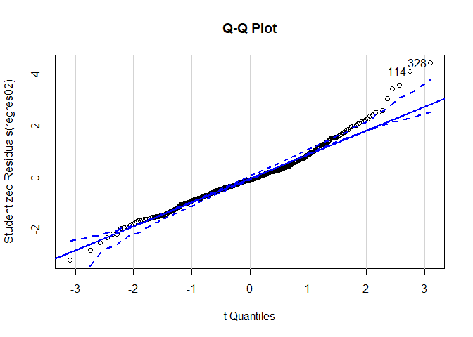

```
## 114 328
## 114 326
```

```r
qqPlot(regres02, labels=row.names(states), id.method="identify",
       simulate=TRUE, main="Q-Q Plot")
```

### Kernel+hist+normalidad

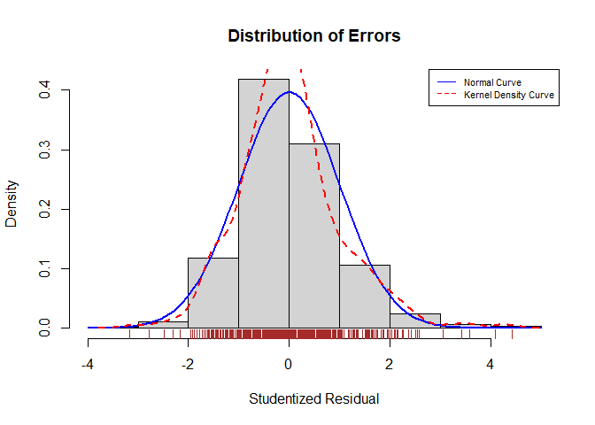

### Linealidad

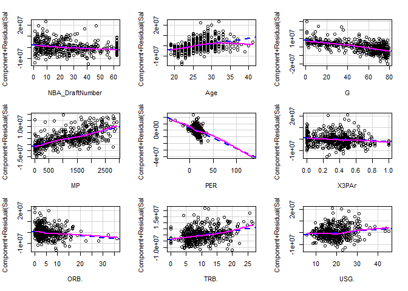

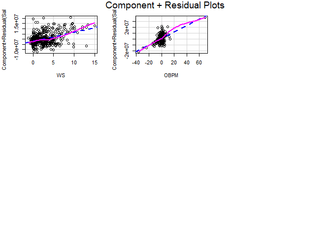

### Heterocedasticidad: rechazamos la hipotesis de homocedasticidad

```
## Non-constant Variance Score Test
## Variance formula: ~ fitted.values
## Chisquare = 93.04367, Df = 1, p = < 2.22e-16
```

### Heterocedasticidad grafica

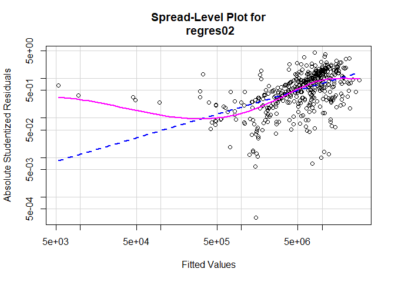

```
##
## Suggested power transformation:  0.4014307
```

### Problemas de colinealidad

#### Vemos que lo hay, porque varios superan el **2**

```r
sqrt(vif(regres02)) > 2
```

```
## NBA_DraftNumber             Age               G              MP             PER
##           FALSE           FALSE            TRUE            TRUE            TRUE
##           X3PAr            ORB.            TRB.            USG.              WS
##           FALSE           FALSE            TRUE           FALSE           FALSE
##            OBPM
##            TRUE
```

```r
## Analisis de valores atipicos
```

```
##     rstudent unadjusted p-value Bonferroni p
## 328 4.418019         1.2388e-05    0.0059588
## 114 4.097004         4.9325e-05    0.0237250
```

### Representacion grafica de los outliers: Parecen ser influyentes

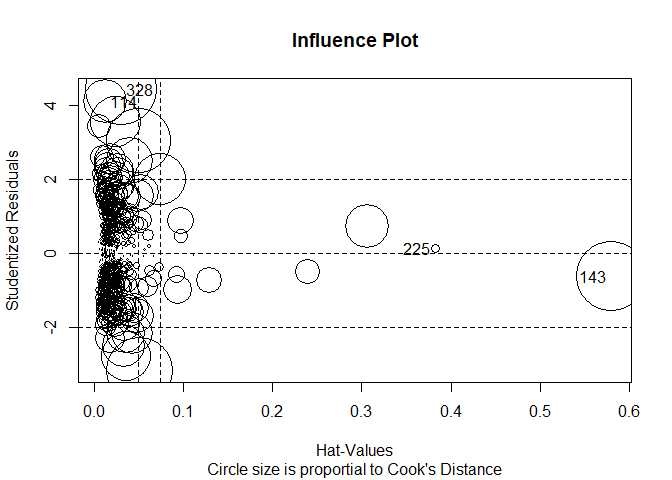

```
##        StudRes        Hat        CookD
## 114  4.0970044 0.01335831 0.0183217443
## 143 -0.6387408 0.57925981 0.0468679555
## 225  0.1211155 0.38197382 0.0007571094
## 328  4.4180190 0.03106963 0.0501763187
```

## Importancia de las variables

### Aplicamos la funcion

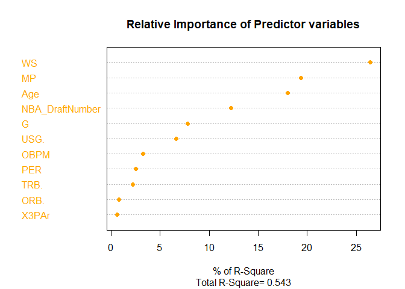

```
##                    Weights
## X3PAr            0.6091415
## ORB.             0.8426545
## TRB.             2.2368562
## PER              2.5104005
## OBPM             3.2774649
## USG.             6.6742203
## G                7.8423530
## NBA_DraftNumber 12.2338554
## Age             18.0024613
## MP              19.3329810
## WS              26.4376113
```

## Hacemos el modelo de prediccion

### Con una muestra de diez observaciones

```
## [1] 483
```

```
##               Player   Salary NBA_Country NBA_DraftNumber Age  Tm  G   MP  PER
## 286      Jason Smith  5225000         USA              20  31 WAS 31  276  8.2
## 338      Gary Harris  2550055         USA              19  23 DEN 65 2265 16.6
## 408 D'Angelo Russell  5562360         USA               2  21 BRK 44 1124 15.5
## 101   Richaun Holmes  1471382         USA              37  24 PHI 44  668 16.8
## 111 Quincy Pondexter  3853931         USA              26  29 CHI 23  196  4.0
## 395    Davis Bertans  1312611      Latvia              42  25 SAS 74 1067 14.2
## 133     Nikola Jokic  1471382      Serbia              41  22 DEN 71 2288 24.4
## 424       Chris Paul 24599495         USA               4  32 HOU 55 1753 24.3
## 402      Dario Saric  2422560     Croatia              12  23 PHI 74 2229 16.1
## 390  DeAndre Liggins  1577230         USA              53  29 TOT 55  711  6.2
##       TS. X3PAr   FTr ORB. DRB. TRB. AST. STL. BLK. TOV. USG.  OWS DWS   WS
## 286 0.444 0.277 0.170  7.4 13.9 10.7  7.6  0.5  3.8 11.7 21.9 -0.3 0.2 -0.1
## 338 0.599 0.436 0.175  1.8  6.8  4.3 13.1  2.6  0.6 11.0 20.6  3.9 1.4  5.4
## 408 0.506 0.398 0.209  2.7 14.2  8.4 35.6  1.4  1.1 16.2 30.7 -0.4 0.8  0.4
```

[output cut: 18 more lines]

## Hacemos la prediccion, y sacamos el salario de cada jugador

```
##        286        338        408        101        111        395        133
##  5812043.7 11205194.1  6446277.3  4114492.8  4110509.4  1253707.1 15201985.8
##        424        402        390
## 20748503.2 12199777.0   601566.5
```